# flowWorkspace Introduction: A Package to store and maninpulate gated flow data

Greg Finak gfinak@fhcrc.org, Mike Jiang wjiang2@fhcrc.org

## 0.1 Purpose

The purpose of this package is to provide the infrastructure to store, represent and exchange gated flow data. By this we mean accessing the samples, groups, transformations, compensation matrices, gates, and population statistics in the gating tree, which is represented as a `GatingSet` object in `R`.

There are several ways to generate a `GatingSet`: * built from scratch within `R` (which will be demonstrated later) * imported from the XML workspace files exported from other software (e.g. FlowJo, Diva, CytoBank). Details on the importing xml are documented in [CytoML](https://www.bioconductor.org/packages/release/bioc/html/CytoML.html) package. * generated by automated gating framework from [openCyto](https://www.bioconductor.org/packages/release/bioc/html/openCyto.html) package * loaded from the existing GatingSet archive (that was previously saved by `save_gs()` call)

Here we simply load an example `GatingSet` archive to illustrate how to interact with a `GatingSet` object.

```r
library(flowWorkspace)
dataDir <- system.file("extdata",package="flowWorkspaceData")
gs_archive <- list.files(dataDir, pattern = "gs_bcell_auto",full = TRUE)
gs <- load_gs(gs_archive)
gs
```

```
## A GatingSet with 2 samples
```

We have loaded a `GatingSet` with 2 samples, each of which has 14 associated gates.

To list the samples stored in `GatingSet`:

```r
sampleNames(gs)
```

```
## [1] "12828_1_Bcell_C01.fcs" "12828_2_Bcell_C02.fcs"
```

## 0.2 Basics on GatingSet

Subsets of a `GatingSet` can be accessed using the standard R subset syntax `[`.

```r
gs[1]
```

```
## A GatingSet with 1 samples
```

We can plot the gating tree:

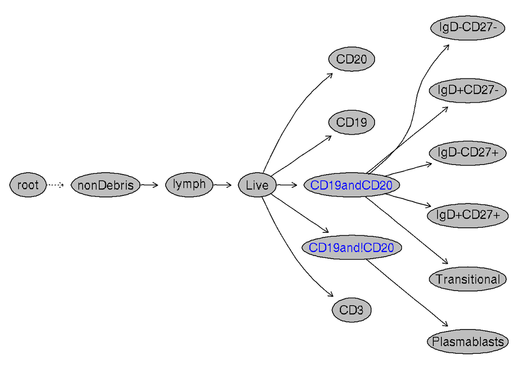

```r
plot(gs, bool = TRUE)
```

The boolean gates(notes) are highlighted in blue color.

We can list the nodes (populations) in the gating hierarchy:

```r
gs_get_pop_paths(gs, path = 2)
```

```
##  [1] "root"                      "boundary/nonDebris"
##  [3] "nonDebris/lymph"           "lymph/Live"
##  [5] "Live/CD20"                 "Live/CD19"
##  [7] "Live/CD19andCD20"          "CD19andCD20/IgD-CD27-"
##  [9] "CD19andCD20/IgD+CD27-"     "CD19andCD20/IgD-CD27+"
## [11] "CD19andCD20/IgD+CD27+"     "CD19andCD20/Transitional"
## [13] "Live/CD19and!CD20"         "CD19and!CD20/Plasmablasts"
## [15] "Live/CD3"
```

Note that the `path` argument specifies the depth of the gating path for each population. As shown, `depth` of `1` (i.e. leaf or terminal node name) may not be sufficient to uniquely identify each population. The issue can be resolved by increasing the `path` or simply returning the full path of the node:

```r
gs_get_pop_paths(gs, path = "full")
```

```
##  [1] "root"
##  [2] "/boundary/nonDebris"
##  [3] "/boundary/nonDebris/lymph"
##  [4] "/boundary/nonDebris/lymph/Live"
##  [5] "/boundary/nonDebris/lymph/Live/CD20"
##  [6] "/boundary/nonDebris/lymph/Live/CD19"
##  [7] "/boundary/nonDebris/lymph/Live/CD19andCD20"
##  [8] "/boundary/nonDebris/lymph/Live/CD19andCD20/IgD-CD27-"
##  [9] "/boundary/nonDebris/lymph/Live/CD19andCD20/IgD+CD27-"
## [10] "/boundary/nonDebris/lymph/Live/CD19andCD20/IgD-CD27+"
## [11] "/boundary/nonDebris/lymph/Live/CD19andCD20/IgD+CD27+"
## [12] "/boundary/nonDebris/lymph/Live/CD19andCD20/Transitional"
## [13] "/boundary/nonDebris/lymph/Live/CD19and!CD20"
## [14] "/boundary/nonDebris/lymph/Live/CD19and!CD20/Plasmablasts"
## [15] "/boundary/nonDebris/lymph/Live/CD3"
```

But `full` path may not be necessary and could be too long to be visualized. So we provide the `path = 'auto'` option to determine the shortest path that is still unique within the gating tree.

```r
nodelist <- gs_get_pop_paths(gs, path = "auto")
nodelist
```

```
##  [1] "root"         "nonDebris"    "lymph"        "Live"         "CD20"
##  [6] "CD19"         "CD19andCD20"  "IgD-CD27-"    "IgD+CD27-"    "IgD-CD27+"
## [11] "IgD+CD27+"    "Transitional" "CD19and!CD20" "Plasmablasts" "CD3"
```

We can get the gate associated with the specific population:

```r
node <- nodelist[3]
g <- gs_pop_get_gate(gs, node)
g
```

```
## $`12828_1_Bcell_C01.fcs`
## Ellipsoid gate 'lymph' in dimensions FSC-A and SSC-A
##
## $`12828_2_Bcell_C02.fcs`
## Ellipsoid gate 'lymph' in dimensions FSC-A and SSC-A
```

We can retrieve the population statistics :

```r
gs_pop_get_stats(gs)[1:10,]
```

```
##                    sample                                                  pop
##  1: 12828_1_Bcell_C01.fcs                                                 root
##  2: 12828_1_Bcell_C01.fcs                                  /boundary/nonDebris
##  3: 12828_1_Bcell_C01.fcs                            /boundary/nonDebris/lymph
##  4: 12828_1_Bcell_C01.fcs                       /boundary/nonDebris/lymph/Live
##  5: 12828_1_Bcell_C01.fcs                  /boundary/nonDebris/lymph/Live/CD20
##  6: 12828_1_Bcell_C01.fcs                  /boundary/nonDebris/lymph/Live/CD19
##  7: 12828_1_Bcell_C01.fcs           /boundary/nonDebris/lymph/Live/CD19andCD20
##  8: 12828_1_Bcell_C01.fcs /boundary/nonDebris/lymph/Live/CD19andCD20/IgD-CD27-
##  9: 12828_1_Bcell_C01.fcs /boundary/nonDebris/lymph/Live/CD19andCD20/IgD+CD27-
## 10: 12828_1_Bcell_C01.fcs /boundary/nonDebris/lymph/Live/CD19andCD20/IgD-CD27+
##     count
##  1: 81638
##  2: 80711
##  3: 52927
##  4: 51652
##  5: 11093
##  6: 11126
##  7: 11028
##  8:   765
##  9:  9219
## 10:   590
```

We can plot individual gates. Note the scale of the transformed axes. The second argument is the node path of any depth as long as it is uniquely identifiable.

```r
library(ggcyto)
```

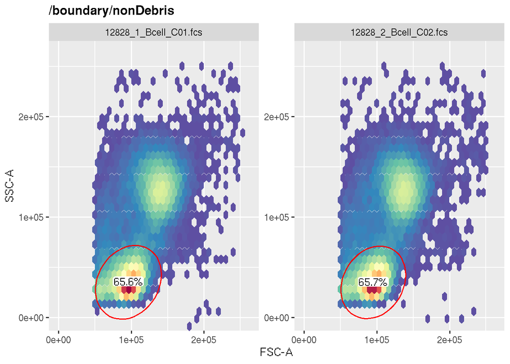

```r
autoplot(gs, node)
```

More details about gate visualization can be found [here](http://bioconductor.org/packages/release/bioc/html/ggcyto.html).

If we have metadata associated with the experiment, it can be attached to the `GatingSet`.

```r
d <- data.frame(sample=factor(c("sample 1", "sample 2")),treatment=factor(c("sample","control")) )
pd <- pData(gs)
pd <- cbind(pd,d)
pData(gs) <- pd
pData(gs)
```

```
##                         sample                  name treatment Center Replicate
## 12828_1_Bcell_C01.fcs sample 1 12828_1_Bcell_C01.fcs    sample  NHLBI         1
## 12828_2_Bcell_C02.fcs sample 2 12828_2_Bcell_C02.fcs   control  NHLBI         2
##                       Sample
## 12828_1_Bcell_C01.fcs  12828
## 12828_2_Bcell_C02.fcs  12828
```

We can subset the `GatingSet` by its `pData` directly:

```r
subset(gs, treatment == "control")
```

```
## A GatingSet with 1 samples
```

The underlying `flow data` can be retrieved by:

```r
cs <- gs_pop_get_data(gs)
class(cs)
```

```
## [1] "cytoset"
## attr(,"package")
## [1] "flowWorkspace"
```

```r
nrow(cs[[1]])
```

```
## [1] 81638
```

Because `GatingSet` is a purely reference class, the class type returned by `gs_pop_get_data` is a `cytoset`, which is the purely reference class analog of a `flowSet` and will be discussed in more detail below. Also note that the data is already compensated and transformed during the parsing.

We can retrieve the subset of data associated with a population node:

```r
cs <- gs_pop_get_data(gs, node)
nrow(cs[[1]])
```

```
## [1] 52927
```

## 0.3 GatingHierarchy

We can retrieve a single gating hierarchical tree (corresponding to one sample) by using the `[[` extraction operator

```r
gh <- gs[[1]]
gh
```

```
## Sample:  12828_1_Bcell_C01.fcs
## GatingHierarchy with  15  gates
```

Note that the index can be either numeric or character (the `guid` returned by the `sampleNames` method)

The `autoplot` method without specifying any node will lay out all the gates in the same plot

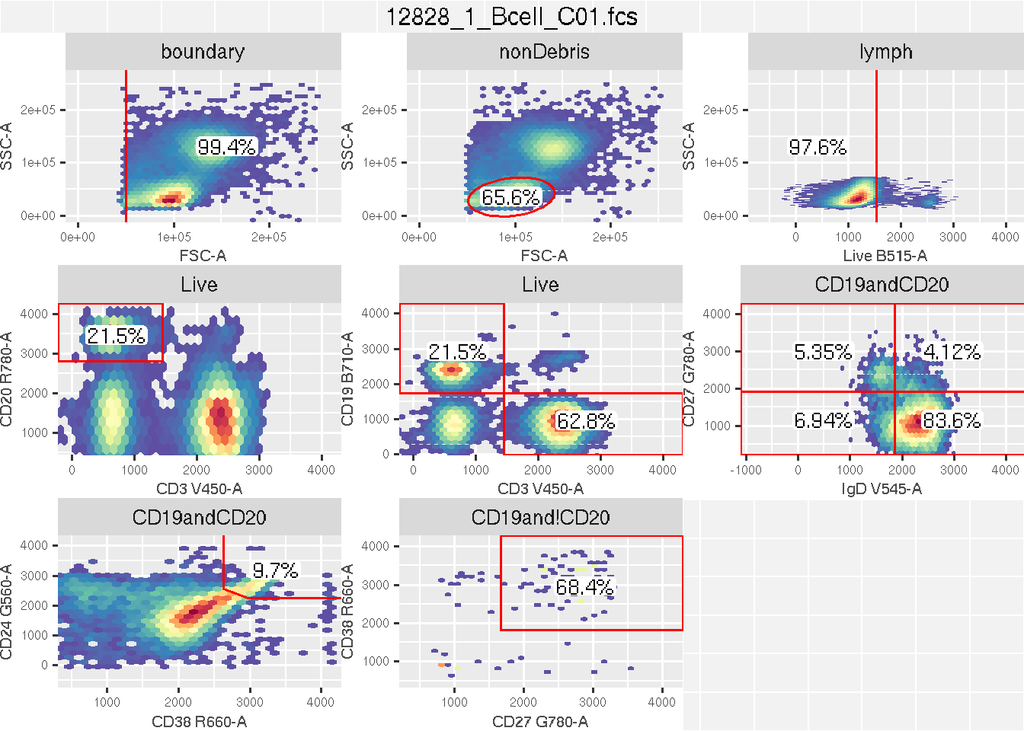

```r
autoplot(gh)
```

We can retrieve the indices specifying if an event is included inside or outside a gate using:

```r
table(gh_pop_get_indices(gh,node))
```

```
##
## FALSE  TRUE
## 28711 52927
```

## 0.4 Build the GatingSet from scratch

`GatingSet` provides methods to build a gating tree from raw FCS files and add or remove flowCore gates (or populations) to or from it.

```r
library(flowCore)
data(GvHD)
#select raw flow data
fs <- GvHD[1:2]
```

Then construct a `GatingSet` from the `flowSet`:

```r
gs <- GatingSet(fs)
```

Then compensate it:

```r
cfile <- system.file("extdata","compdata","compmatrix", package="flowCore")
comp.mat <- read.table(cfile, header=TRUE, skip=2, check.names = FALSE)
## create a compensation object
comp <- compensation(comp.mat)
#compensate GatingSet
gs <- compensate(gs, comp)
```

**New**: You can now pass a list of `compensation` objects with elements named by `sampleNames(gs)` to achieve sample-specific compensations. e.g.

```r
gs <- compensate(gs, comp.list)
```

Then we can transform it with any transformation defined by the user through `trans_new` function of `scales` package.

```r
require(scales)
trans.func <- asinh
inv.func <- sinh
trans.obj <- trans_new("myAsinh", trans.func, inv.func)
```

The `inverse` transformation is required so that the gates and data can be visualized in `transformed` scale while the axis label still remains in the raw scale. Optionally, the `breaks` and `format` functions can be supplied to further customize the appearance of axis labels.

Besides doing all these by hand, we also provide some buildin transformations: `asinhtGml2_trans`, `flowjo_biexp_trans`, `flowjo_fasinh_trans` and `logicle_trans`. These are all very commonly used transformations in flow data analysis. User can construct the transform object by simply one-line of code. e.g.

```r
trans.obj <- asinhtGml2_trans()
trans.obj
```

```
## Transformer:  asinhtGml2
```

Once a `transformer` object is created, we must convert it to `transformerList` for `GatingSet` to use.

```r
chnls <- colnames(fs)[3:6]
transList <- transformerList(chnls, trans.obj)
```

Alternatively, the overloaded `estimateLogicle` method can be used directly on `GatingHierarchy` to generate a `transformerList` object automatically.

```r
estimateLogicle(gs[[1]], chnls)
```

```
## $`FL1-H`
## Transformer:  logicle
##
## $`FL2-H`
## Transformer:  logicle
##
## $`FL3-H`
## Transformer:  logicle
##
## $`FL2-A`
## Transformer:  logicle
##
## attr(,"class")
## [1] "transformerList" "list"
```

Now we can transform our `GatingSet` with this `transformerList` object. It will also store the transformation in the `GatingSet` and can be used to inverse-transform the data.

```r
gs <- transform(gs, transList)
gs_get_pop_paths(gs)
```

```
## [1] "root"
```

It now only contains the root node. We can add our first `rectangleGate`:

```r
rg <- rectangleGate("FSC-H"=c(200,400), "SSC-H"=c(250, 400), filterId="rectangle")
nodeID <- gs_pop_add(gs, rg)
nodeID
```

```
## [1] 2
```

```r
gs_get_pop_paths(gs)
```

```
## [1] "root"       "/rectangle"
```

Note that the gate is added to the root node by default if the parent is not specified. Then we add a `quadGate` to the new population generated by the `rectangleGate` which is named after the `filterId` of the gate because the name was not specified when the `add` method was called.

```r
qg <- quadGate("FL1-H"= 0.2, "FL2-H"= 0.4)
nodeIDs <- gs_pop_add(gs,qg,parent="rectangle")
nodeIDs
```

```
## [1] 3 4 5 6
```

```r
gs_get_pop_paths(gs)
```

```
## [1] "root"                          "/rectangle"
## [3] "/rectangle/CD15 FITC-CD45 PE+" "/rectangle/CD15 FITC+CD45 PE+"
## [5] "/rectangle/CD15 FITC+CD45 PE-" "/rectangle/CD15 FITC-CD45 PE-"
```

Here `quadGate` produces four population nodes/populations named after the dimensions of the gate if names are not specified.

A Boolean gate can also be defined and added to GatingSet:

```r
bg <- booleanFilter(`CD15 FITC-CD45 PE+|CD15 FITC+CD45 PE-`)
bg
```

```
## booleanFilter filter 'CD15 FITC-CD45 PE+|CD15 FITC+CD45 PE-' evaluating the expression:
## CD15 FITC-CD45 PE+|CD15 FITC+CD45 PE-
```

```r
nodeID2 <- gs_pop_add(gs,bg,parent="rectangle")
nodeID2
```

```
## [1] 7
```

```r
gs_get_pop_paths(gs)
```

```
## [1] "root"
## [2] "/rectangle"
## [3] "/rectangle/CD15 FITC-CD45 PE+"
## [4] "/rectangle/CD15 FITC+CD45 PE+"
## [5] "/rectangle/CD15 FITC+CD45 PE-"
## [6] "/rectangle/CD15 FITC-CD45 PE-"
## [7] "/rectangle/CD15 FITC-CD45 PE+|CD15 FITC+CD45 PE-"
```

The gating hierarchy is plotted by:

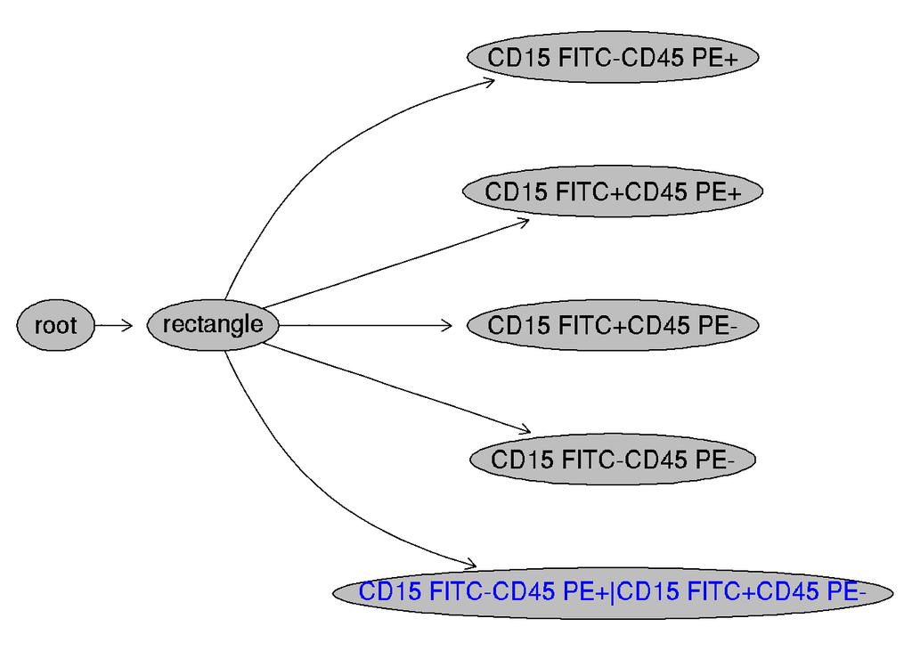

```r
plot(gs, bool=TRUE)
```

Note that Boolean gate is skipped by default and thus needs to be enabled explictily.

Now all the gates are added to the gating tree but the actual data is not gated yet. This is done by calling the `recompute` method explictily:

```r
recompute(gs)
```

After gating is finished, gating results can be visualized by the `autoplot` method:

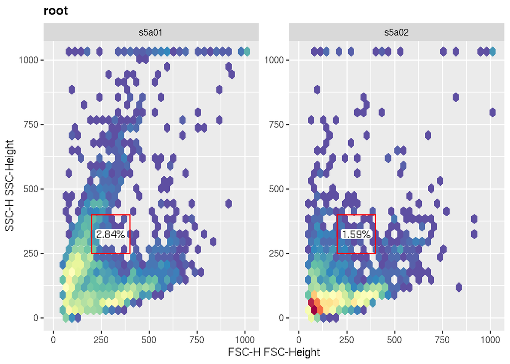

```r
autoplot(gs,"rectangle") #plot one Gate
```

Multiple gates can be plotted on the same panel:

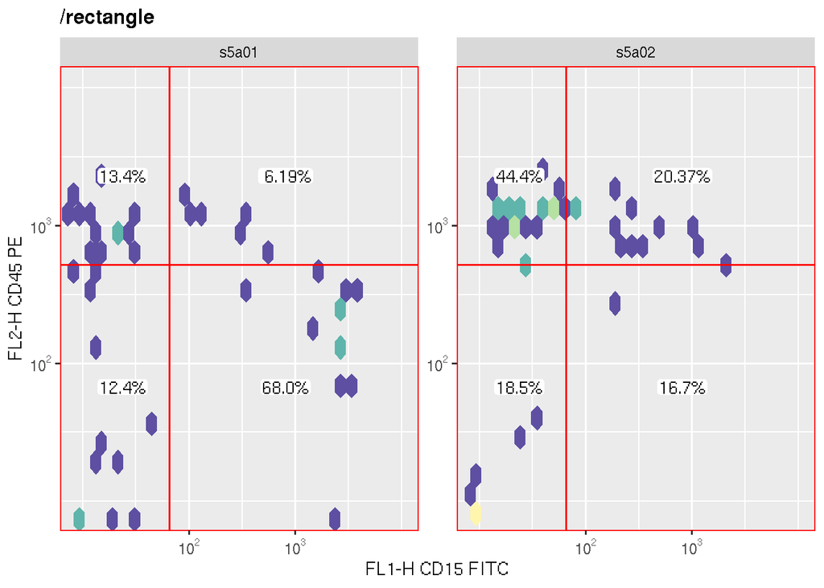

```r
autoplot(gs, gs_pop_get_children(gs[[1]], "rectangle")[1:4])
```

We may also want to plot all the gates without specifying the gate index:

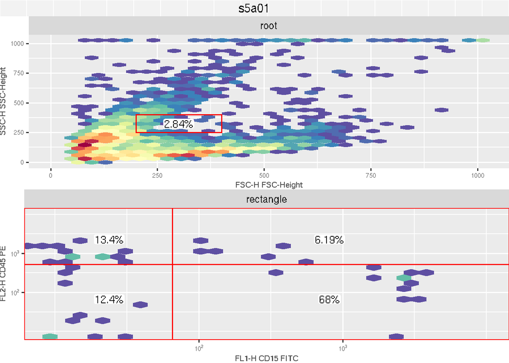

```r
autoplot(gs[[1]])
```

We can retrieve all the compensation matrices from the `GatingHierarchy` in case we wish to use the compensation or transformation for the new data,

```r
gh <- gs[[1]]
gh_get_compensations(gh);
```

```
## Compensation object 'defaultCompensation':
##          FL1-H    FL2-H   FL3-H   FL4-H
## FL1-H 1.000000 0.240000 0.03200 0.00113
## FL2-H 0.007770 1.000000 0.14000 0.00274
## FL3-H 0.008690 0.170000 1.00000 0.21000
## FL4-H 0.000795 0.000995 0.00323 1.00000
```

Or we can retrieve transformations:

```r
trans <- gh_get_transformations(gh)
names(trans)
```

```
## [1] "FL1-H" "FL2-A" "FL2-H" "FL3-H"
```

```r
trans[[1]]
```

```
## function (x)
## {
##     length * ((asinh(x * sinh(m * log(10))/t) + a * log(10))/((m +
##         a) * log(10)))
## }
## <bytecode: 0x558872186340>
## <environment: 0x55886efa2b48>
## attr(,"type")
## [1] "fasinh"
```

If we want to remove one node, simply:

```r
Rm('rectangle', gs)
gs_get_pop_paths(gs)
```

```
## [1] "root"
```

As we see, removing one node causes all its descendants to be removed as well.

### 0.4.1 Archive and Clone

Oftentimes, we need to save a `GatingSet` including the gated flow data, gates, and populations to disk and reload it later on. This can be done by:

```r
tmp <- tempdir()
save_gs(gs,path = file.path(tmp,"my_gs"))
gs <- load_gs(file.path(tmp,"my_gs"))
```

We also provide the `gs_clone` method to make a full copy of an existing `GatingSet`:

```r
gs1 <- gs_clone(gs)
```

To only copy the gates and populations without copy the underlying cyto data.

```r
gs2 <- gs_copy_tree_only(gs)
```

This is a lightweight copying which is faster than `gs_clone`. But be aware the new `GatingSet` share the same events data (i.e. `gs_cyto_data(gs)`) with the original one.

Note that the `GatingSet` is a purely reference class with an external pointer that points to the internal ‘C’ data structure. So make sure to use these methods in order to save or make a copy of an existing `GatingSet` object. The regular R assignment (<-) or `save` routine doesn’t work as expected for `GatingSet` objects.

## 0.5 The cytoframe and cytoset classes

The `GatingSet` class no longer uses `flowFrame` and `flowSet` objects for containing the underlying flow data, but rather now uses the analogous `cytoframe` and `cytoset` classes. `cytoframe` and `cytoset` are essentially reference classes with pointers to internal ‘C’ data structures and thus enable `GatingSet` operations to be performed more efficiently.

While working with `GatingSet` objects will often entail working with `cytoframe` and `cytoset` objects implicitly, it is also possible to directly work with objects of both of these classes.

### 0.5.1 Reading a `cytoframe`

Instead of `read.FCS()`, `cytoframe` objects can be created from FCS files with the `load_cytoframe_from_fcs()` method. The optional `num_threads` argument allows for parallelization of the read operation.

```r
files <- list.files(dataDir, "Cyto", full.names = TRUE)
cf <- load_cytoframe_from_fcs(files[1], num_threads = 4)
cf
```

```
## cytoframe object 'CytoTrol_CytoTrol_1.fcs'
## with 119531 cells and 12 observables:
##        name         desc  range minRange maxRange
## $P1   FSC-A         <NA> 262143        0   262143
## $P2   FSC-H         <NA> 262143        0   262143
## $P3   FSC-W         <NA> 262143        0   262143
## $P4   SSC-A         <NA> 262143        0   262143
## $P5  B710-A  CD4 PcpCy55 262143     -111   262143
## $P6  R660-A     CD38 APC 262143     -111   262143
## $P7  R780-A    CD8 APCH7 262143     -111   262143
## $P8  V450-A     CD3 V450 262143     -111   262143
## $P9  V545-A  HLA-DR V500 262143     -111   262143
## $P10 G560-A      CCR7 PE 262143     -111   262143
## $P11 G780-A CD45RA PECy7 262143     -111   262143
## $P12   Time         <NA> 262143        0   262143
## 199 keywords are stored in the 'description' slot
```

Instead of using `read.FCSheader()` to obtain only the header of the file, just use the `text.only` argument to `load_cytoframe_from_fcs()`.

```r
cfh <- load_cytoframe_from_fcs(files[1], text.only = TRUE)
cfh
```

```
## cytoframe object 'CytoTrol_CytoTrol_1.fcs'
## with 119531 cells and 12 observables:
##        name         desc  range minRange maxRange
## $P1   FSC-A         <NA> 262143        0   262143
## $P2   FSC-H         <NA> 262143        0   262143
## $P3   FSC-W         <NA> 262143        0   262143
## $P4   SSC-A         <NA> 262143        0   262143
## $P5  B710-A  CD4 PcpCy55 262143     -111   262143
## $P6  R660-A     CD38 APC 262143     -111   262143
## $P7  R780-A    CD8 APCH7 262143     -111   262143
## $P8  V450-A     CD3 V450 262143     -111   262143
## $P9  V545-A  HLA-DR V500 262143     -111   262143
## $P10 G560-A      CCR7 PE 262143     -111   262143
## $P11 G780-A CD45RA PECy7 262143     -111   262143
## $P12   Time         <NA> 262143        0   262143
## 199 keywords are stored in the 'description' slot
```

### 0.5.2 `cytoframe` Accessors

The accessor methods function the same as they would for a `flowFrame`

```r
dim(cf)
```

```
##     events parameters
##     119531         12
```

```r
colnames(cf)
```

```
##  [1] "FSC-A"  "FSC-H"  "FSC-W"  "SSC-A"  "B710-A" "R660-A" "R780-A" "V450-A"
##  [9] "V545-A" "G560-A" "G780-A" "Time"
```

```r
head(exprs(cf))
```

```
##          FSC-A  FSC-H    FSC-W     SSC-A   B710-A   R660-A    R780-A    V450-A
## [1,] 140733.05 133376 69150.98  91113.96 22311.24 35576.07  14302.16 16232.649
## [2,]  26195.32  26207 65506.79  10115.28     5.04   447.93    682.56    43.700
## [3,]  64294.02  51594 81667.89 174620.03   371.28   851.62    -66.36   335.350
## [4,] 128393.87 103613 81210.08 150625.44  1494.36  5672.20   2979.09  1492.450
## [5,] 127717.88 119616 69974.92  76954.91  2545.20  2272.83 124635.93  8608.899
## [6,] 134347.02 125651 70071.60  70116.48 23052.96  1758.54   5281.15  4849.750
##        V545-A   G560-A   G780-A Time
## [1,]  7644.65  4113.60 12672.00  0.2
## [2,]    77.90   -91.20    18.24  0.4
## [3,]   971.85   273.60   271.68  0.6
## [4,] 28790.70   771.84   988.80  0.6
## [5,]  4190.45 14306.88 58977.60  0.7
## [6,]  2859.50  2249.28  1560.96  0.7
```

```r
spillover(cf)
```

```
## $SPILL
##            B710-A       R660-A       R780-A       V450-A      V545-A
## [1,] 1.000000e+00 3.143890e-02 0.1909655363 3.057568e-03 0.002047231
## [2,] 5.537983e-03 1.000000e+00 0.1768123886 0.000000e+00 0.000000000
## [3,] 9.958625e-05 9.847661e-03 1.0000000000 0.000000e+00 0.000000000
## [4,] 0.000000e+00 8.909845e-05 0.0000000000 1.000000e+00 0.451194675
## [5,] 2.477092e-03 5.235156e-04 0.0000000000 3.796154e-02 1.000000000
## [6,] 1.172236e-01 1.642721e-03 0.0003321532 0.000000e+00 0.000000000
## [7,] 1.420516e-02 4.568956e-04 0.1754022374 8.902497e-05 0.000000000
##            G560-A      G780-A
## [1,] 3.442413e-04 0.071933810
## [2,] 0.000000e+00 0.006618897
## [3,] 0.000000e+00 0.035399709
## [4,] 1.082746e-04 0.000000000
## [5,] 6.361807e-05 0.000000000
## [6,] 1.000000e+00 0.009219359
## [7,] 4.096870e-02 1.000000000
##
## $spillover
## NULL
##
## $`$SPILLOVER`
## NULL
```

```r
head(keyword(cf))
```

```
## $FCSversion
## [1] "3"
##
## $`$BEGINANALYSIS`
## [1] "0"
##
## $`$ENDANALYSIS`
## [1] "0"
##
## $`$BEGINSTEXT`
## [1] "0"
##
## $`$ENDSTEXT`
## [1] "0"
##
## $`$BEGINDATA`
## [1] "3264"
```

### 0.5.3 Pass By Reference

As `cytoframe` and `cytoset` are reference classes, copying objects of either class by the assignment operator (`<-`) will simply provide a copy of the external pointer and so changes made to the copy will also affect the original object.

```r
cf1 <- cf # cf is a reference
colnames(cf1)[1]
```

```
## [1] "FSC-A"
```

```r
colnames(cf1)[1] <- "t"
colnames(cf)[1] # The change affects the original cf object
```

```
## [1] "t"
```

### 0.5.4 Views

Extracting a subset of a `cytoframe` is not computationally intensive, as it merely constructs a view of the data of the original `cytoframe`. However, both objects still share the same underlying pointer to all of the data and thus changes to a view will affect the data of the original `cytoframe`.

```r
cf1 <- cf[1:10, 2:3]
dim(cf1)
```

```
##     events parameters
##         10          2
```

```r
exprs(cf)[2,3]
```

```
##    FSC-W
## 65506.79
```

```r
exprs(cf1)[2,2] <- 0 # data change affects the orignal cf
exprs(cf)[2,3]
```

```
## FSC-W
##     0
```

To construct a new view of an entire `cytoframe`, use the `[]` method rather than the `<-` operator. This will ensure that a new view is created to the full underlying dataset.

```r
cf1 <- cf[]
```

### 0.5.5 Deep Copy

It is also possible to perform a deep copy of a `cytoframe` or a view of it, resulting in two objects pointing to distinct C-level representations of the data. This is accomplished with the `realize_view` method.

```r
cf <- load_cytoframe_from_fcs(files[1], num_threads = 4) # starting fresh
cf1 <- realize_view(cf[1:10, 2:3])
dim(cf1)
```

```
##     events parameters
##         10          2
```

```r
exprs(cf)[2,3]
```

```
##    FSC-W
## 65506.79
```

```r
exprs(cf1)[2,2] <- 0 # data change no longer affects the original cf
exprs(cf)[2,3]
```

```
##    FSC-W
## 65506.79
```

```r
exprs(cf1)[2,2] # but does affect the separate data of cf1
```

```
## FSC-W
##     0
```

Similarly, if a deep copy of all of the data is desired (not a subset), simply call `realize_view` on the original `cytoframe`.

### 0.5.6 Interconversion between `cytoframe` and `flowFrame`

Conversion of objects between the `cytoframe` and `flowFrame` classes is accomplished with a few coercion methods

```r
fr <- cytoframe_to_flowFrame(cf)
class(fr)
```

```
## [1] "flowFrame"
## attr(,"package")
## [1] "flowCore"
```

```r
cf_back <- flowFrame_to_cytoframe(fr)
class(cf_back)
```

```
## [1] "cytoframe"
## attr(,"package")
## [1] "flowWorkspace"
```

Of course (as a side note), here `flowFrame_to_cytoframe()` had no knowledge of the `cytoframe` origin of `fr`, so `cf_back` points to a new copy of the underlying data.

```r
identical(cf@pointer, cf_back@pointer) # These point to distinct copies of the data
```

```
## [1] FALSE
```

### 0.5.7 Saving/Loading a `cytoframe` in h5

A couple of methods handle the task of writing or reading a `cytoframe` in the HDF5 format on disk

```r
tmpfile <- tempfile(fileext = ".h5")
cf_write_h5(cf, tmpfile)
loaded <- load_cytoframe(tmpfile)
```

### 0.5.8 `cytoset` methods

Most of the above methods for `cytoframe` objects have `cytoset` analogs.

For reading in a `cytoset` from FCS files, use `load_cytoset_from_fcs`

```r
files <- list.files(dataDir, "Cyto", full.names = TRUE)
cs <- load_cytoset_from_fcs(files, num_threads = 4)
cs
```

```
## A cytoset with 2 samples.
##
##   column names:
##     FSC-A, FSC-H, FSC-W, SSC-A, B710-A, R660-A, R780-A, V450-A, V545-A, G560-A, G780-A, Time
```

Once constructed, it can be saved/loaded through more efficient archive format.

```r
tmp <- tempfile()
save_cytoset(cs, tmp)
cs <- load_cytoset(tmp, backend_readonly = FALSE)
```

note that `backend_readonly` is set to `TRUE` by default to protect the data from accidental changes. So it has to be turned off explicitly if your want to modify the loaded `cs`

The accessor methods function the same as they would for a `flowSet`

```r
colnames(cs)
```

```
##  [1] "FSC-A"  "FSC-H"  "FSC-W"  "SSC-A"  "B710-A" "R660-A" "R780-A" "V450-A"
##  [9] "V545-A" "G560-A" "G780-A" "Time"
```

Subsetting using `[` will work in a manner similar to that for a `flowSet`, but will result in another `cytoset` that is a view in to the data of the original `cytoset`. The `Subset()` method, when called on a `cytoset`, will also return a `cytoset` that is a view in to the orignal data rather than a deep copy.

```r
sub_cs <- cs[1]
```

**Important:** xtraction using `[[` on a `cytoset` will by default return a `cytoframe` and so will represent a reference of the underlying data. Thus, altering the result of the extraction **will** alter the underlying data of the original `cytoset`.

```r
sub_fr <- cs[[1]]
exprs(cs[[1]])[2,2]
```

```
## FSC-H
## 26207
```

```r
exprs(sub_fr)[2,2] <- 0 # This WILL affect the original data
exprs(cs[[1]])[2,2]
```

```
## FSC-H
##     0
```

To return a `flowFrame` that represents a copy of the data of the `original` cytoset, you need to use the `returnType` argument.

```r
sub_cf <- cs[[1, returnType = "flowFrame"]]
exprs(cs[[1]])[2,2]
```

```
## FSC-H
##     0
```

```r
exprs(sub_cf)[2,2] <- 100 # This WILL NOT affect the original data
exprs(cs[[1]])[2,2]
```

```
## FSC-H
##     0
```

Alternatively, if it is easier to remember, `get_cytoframe_from_cs` will accomplish the same goal

```r
sub_cf <- get_cytoframe_from_cs(cs,1)
```

Finally, the `[]` and `realize_view()` methods work in a similar manner for `cytoset` objects as `cytoframe` objects. `[]` will return a view in to the original data while `realize_view()` will perform a deep copy.

## 0.6 Troubleshooting and error reporting

If this package is throwing errors when parsing your workspace, contact the package author by emails for post an issue on https://github.com/RGLab/flowWorkspace/issues. If you can send your workspace by email, we can test, debug, and fix the package so that it works for you. Our goal is to provide a tool that works, and that people find useful.